# Restaurants

We will do an exercise using some more complicated documents but closer to real usage. There is a file containing restaurant information. An array of JSONs that can be easily ingested using mongolite’s import functionality.

```r
library(mongolite)
r <- mongo(db = "test", collection = "restaurants")
r$import(file("restaurants.json"))
```

Done! How many documents are there?

```r
r$count()
```

```
[1] 25359
```

That’s simple enough. Now what? We could try to launch some queries…

```r
r$find(limit = 10)
```

|  | address | borough | cuisine | grades | name | restaurant_id |
| --- | --- | --- | --- | --- | --- | --- |
| 1 |  | Bronx | Bakery |  | Morris Park Bake Shop | 30075445 |
| 2 |  | Brooklyn | Hamburgers |  | Wendy'S | 30112340 |
| 3 |  | Manhattan | Irish |  | Dj Reynolds Pub And Restaurant | 30191841 |
| 4 |  | Brooklyn | American |  | Riviera Caterer | 40356018 |
| 5 |  | Queens | Jewish/Kosher |  | Tov Kosher Kitchen | 40356068 |
| 6 |  | Queens | American |  | Brunos On The Boulevard | 40356151 |
| 7 |  | Staten Island | Jewish/Kosher |  | Kosher Island | 40356442 |
| 8 |  | Brooklyn | Delicatessen |  | Wilken'S Fine Food | 40356483 |
| 9 |  | Brooklyn | American |  | Regina Caterers | 40356649 |
| 10 |  | Brooklyn | Ice Cream, Gelato, Yogurt, Ices |  | Taste The Tropics Ice Cream | 40356731 |

But trying to infer the schema could be really tricky given that each document can be potentially different.

For that it is much easier to use MongoDB’s [Compass](https://www.mongodb.com/products/compass) tool that allows to explore the schema interactively.

[figure not shown]

From there it can be easily explored the information contained inside our collection, the percentage of data belonging to each data type inside a field or even the query to filter said information subset with a simple click.

[figure not shown]

Even if we have geospatial information we can get a map visualizing where each document information is geographically located.

[figure not shown]

Most of what we have done inside this notebook can be done using Compass in a more visual manner. Importing documents for example.

[figure not shown]

Or building aggregation pipelines.

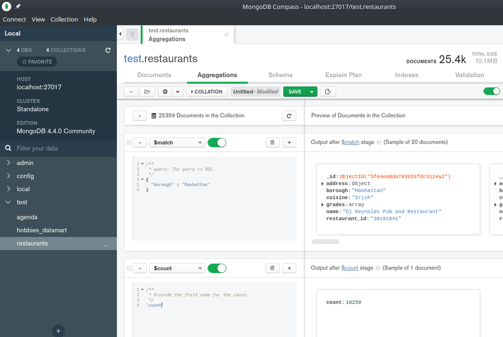

Let’s do some simple exercises.